# Credit Card Default

```r
# This produces the same output with scaled data.
logit_model2 <- glm(default.payment.next.month ~ . , data = train_scaled, family = 'binomial') %>%
  stepAIC(trace = FALSE)

summary(logit_model2)
```

```
##
## Call:
## glm(formula = default.payment.next.month ~ scaled.limit_bal +
##     scaled.bill_amt1 + scaled.bill_amt4 + scaled.bill_amt6 +
##     scaled.pay_amt1 + scaled.pay_amt2 + scaled.pay_amt4 + scaled.pay_amt5 +
##     scaled.pay_amt6 + scaled.bill_avg + scaled.avg_credit_usage +
##     sex + education + marriage + pay_0 + pay_2 + pay_3 + pay_4 +
##     pay_6, family = "binomial", data = train_scaled)
##
## Deviance Residuals:
##     Min       1Q   Median       3Q      Max
## -2.5758  -0.6617  -0.5157  -0.2426   3.9919
##
## Coefficients: (1 not defined because of singularities)
##                          Estimate Std. Error z value             Pr(>|z|)
## (Intercept)              -1.04029    0.06758 -15.394 < 0.0000000000000002 ***
## scaled.limit_bal         -0.37483    0.02921 -12.834 < 0.0000000000000002 ***
## scaled.bill_amt1         -0.28418    0.11649  -2.440             0.014705 *
## scaled.bill_amt4         -0.28203    0.11042  -2.554             0.010646 *
## scaled.bill_amt6         -0.16995    0.08577  -1.981             0.047556 *
## scaled.pay_amt1          -0.29204    0.04465  -6.541      0.0000000000612 ***
## scaled.pay_amt2          -0.23433    0.04865  -4.817      0.0000014578420 ***
## scaled.pay_amt4          -0.13313    0.03298  -4.037      0.0000540730823 ***
## scaled.pay_amt5          -0.09373    0.03071  -3.052             0.002276 **
## scaled.pay_amt6          -0.04049    0.02583  -1.567             0.117019
## scaled.bill_avg           0.97864    0.25182   3.886             0.000102 ***
## scaled.avg_credit_usage   0.26645    0.02963   8.994 < 0.0000000000000002 ***
## sex1                     -0.18767    0.03472  -5.406      0.0000000644202 ***
## education2                0.06361    0.04039   1.575             0.115334
## education3               -0.03077    0.05342  -0.576             0.564611
## education4               -1.34073    0.21777  -6.157      0.0000000007425 ***
## marriage2                -0.18709    0.03546  -5.276      0.0000001320605 ***
## marriage3                -0.13664    0.15451  -0.884             0.376509
## pay_00                   -1.26363    0.08397 -15.049 < 0.0000000000000002 ***
## pay_01                    0.45516    0.07823   5.818      0.0000000059571 ***
## pay_02                    0.74147    0.07602   9.754 < 0.0000000000000002 ***
## pay_03                    1.83765    0.17802  10.322 < 0.0000000000000002 ***
## pay_04                    1.23142    0.35212   3.497             0.000470 ***
## pay_05                    0.55010    0.52889   1.040             0.298288
## pay_06                    0.11229    1.04325   0.108             0.914287
```

[output cut: 32 more lines]

```
## pay_64                    0.86859    0.46200   1.880             0.060101 .
## pay_65                   -0.86300    0.85949  -1.004             0.315338
## pay_66                    0.83944    0.83622   1.004             0.315449
## pay_67                  -11.38331  187.55656  -0.061             0.951604
## pay_68                         NA         NA      NA                   NA
## ---
## Signif. codes:  0 '***' 0.001 '**' 0.01 '*' 0.05 '.' 0.1 ' ' 1
##
## (Dispersion parameter for binomial family taken to be 1)
##
##     Null deviance: 25458  on 23999  degrees of freedom
## Residual deviance: 21671  on 23939  degrees of freedom
## AIC: 21793
##
## Number of Fisher Scoring iterations: 12
```

```r
# Both of these code chunks take a few minutes to complete running.
```

The StepAIC() functions helps to determine which variables to retain in the final model. The following code chunk uses different combinations of the recommended variables in an effort to develop a model with a lower AIC score.

```r
logit_model1B <- glm(default.payment.next.month ~ limit_bal + sex + education + marriage
                     + pay_0 + bill_amt1 + bill_amt4 + bill_amt6
                     + pay_amt1 + pay_amt2 + pay_amt3 + pay_amt4 + pay_amt5 + pay_amt6
                     + bill_avg + avg_credit_usage, data = train, family = 'binomial')

summary(logit_model1B)
```

```
##
## Call:
## glm(formula = default.payment.next.month ~ limit_bal + sex +
##     education + marriage + pay_0 + bill_amt1 + bill_amt4 + bill_amt6 +
##     pay_amt1 + pay_amt2 + pay_amt3 + pay_amt4 + pay_amt5 + pay_amt6 +
##     bill_avg + avg_credit_usage, family = "binomial", data = train)
##
## Deviance Residuals:
##     Min       1Q   Median       3Q      Max
## -2.0305  -0.6652  -0.5231  -0.2439   3.9884
##
## Coefficients:
##                      Estimate   Std. Error z value             Pr(>|z|)
## (Intercept)      -0.671905072  0.071214419  -9.435 < 0.0000000000000002 ***
## limit_bal        -0.000003009  0.000000224 -13.435 < 0.0000000000000002 ***
## sex1             -0.201526885  0.034438335  -5.852   0.0000000048622701 ***
## education2        0.050021171  0.040083111   1.248              0.21205
## education3       -0.035329728  0.052923565  -0.668              0.50441
## education4       -1.372256822  0.217880005  -6.298   0.0000000003010775 ***
## marriage2        -0.187227403  0.035201202  -5.319   0.0000001044660921 ***
## marriage3        -0.151507839  0.153045742  -0.990              0.32220
## pay_00           -0.995566522  0.056952141 -17.481 < 0.0000000000000002 ***
## pay_01            0.416816072  0.059789365   6.971   0.0000000000031378 ***
## pay_02            0.888290577  0.054553131  16.283 < 0.0000000000000002 ***
## pay_03            2.006539330  0.158006595  12.699 < 0.0000000000000002 ***
## pay_04            1.469926682  0.301344034   4.878   0.0000010722014308 ***
## pay_05            0.169665691  0.438840439   0.387              0.69904
## pay_06            1.055408584  0.723427597   1.459              0.14459
## pay_07            0.959383580  0.851039018   1.127              0.25961
## pay_08            0.255045514  0.513596639   0.497              0.61948
## bill_amt1        -0.000003237  0.000001666  -1.943              0.05201 .
## bill_amt4        -0.000002988  0.000001990  -1.502              0.13318
## bill_amt6        -0.000001764  0.000001490  -1.184              0.23647
## pay_amt1         -0.000016485  0.000002562  -6.434   0.0000000001244339 ***
## pay_amt2         -0.000011835  0.000002119  -5.584   0.0000000234639987 ***
## pay_amt3         -0.000003659  0.000001875  -1.952              0.05098 .
## pay_amt4         -0.000008927  0.000002153  -4.146   0.0000337769254713 ***
## pay_amt5         -0.000006540  0.000001995  -3.278              0.00104 **
## pay_amt6         -0.000002445  0.000001483  -1.649              0.09919 .
## bill_avg          0.000012475  0.000004371   2.854              0.00432 **
## avg_credit_usage  0.614437509  0.078855072   7.792   0.0000000000000066 ***
## ---
## Signif. codes:  0 '***' 0.001 '**' 0.01 '*' 0.05 '.' 0.1 ' ' 1
##
## (Dispersion parameter for binomial family taken to be 1)
##
##     Null deviance: 25458  on 23999  degrees of freedom
## Residual deviance: 21905  on 23972  degrees of freedom
## AIC: 21961
##
## Number of Fisher Scoring iterations: 6
```

```r
logit_model2B <- glm(default.payment.next.month ~ scaled.limit_bal + sex + education + marriage
                     + pay_0 + scaled.bill_amt1 + scaled.bill_amt4 + scaled.bill_amt6
                     + scaled.pay_amt1 + scaled.pay_amt2 + scaled.pay_amt3 + scaled.pay_amt4 + scaled.pay_amt5
                     + scaled.bill_avg + scaled.avg_credit_usage, data = train_scaled, family = 'binomial')

summary(logit_model2B)
```

```
##
## Call:
## glm(formula = default.payment.next.month ~ scaled.limit_bal +
##     sex + education + marriage + pay_0 + scaled.bill_amt1 + scaled.bill_amt4 +
##     scaled.bill_amt6 + scaled.pay_amt1 + scaled.pay_amt2 + scaled.pay_amt3 +
##     scaled.pay_amt4 + scaled.pay_amt5 + scaled.bill_avg + scaled.avg_credit_usage,
##     family = "binomial", data = train_scaled)
##
## Deviance Residuals:
##     Min       1Q   Median       3Q      Max
## -2.0320  -0.6654  -0.5233  -0.2458   3.8790
##
## Coefficients:
##                         Estimate Std. Error z value             Pr(>|z|)
## (Intercept)             -1.01954    0.05725 -17.809 < 0.0000000000000002 ***
## scaled.limit_bal        -0.39355    0.02900 -13.570 < 0.0000000000000002 ***
## sex1                    -0.20167    0.03444  -5.856  0.00000000473994061 ***
## education2               0.04986    0.04008   1.244              0.21349
## education3              -0.03492    0.05292  -0.660              0.50933
## education4              -1.37528    0.21799  -6.309  0.00000000028113317 ***
## marriage2               -0.18797    0.03520  -5.341  0.00000009264659393 ***
## marriage3               -0.15041    0.15307  -0.983              0.32580
## pay_00                  -0.99290    0.05692 -17.444 < 0.0000000000000002 ***
## pay_01                   0.41915    0.05978   7.012  0.00000000000235085 ***
## pay_02                   0.88943    0.05454  16.307 < 0.0000000000000002 ***
## pay_03                   2.00718    0.15799  12.705 < 0.0000000000000002 ***
## pay_04                   1.47094    0.30171   4.875  0.00000108578800893 ***
## pay_05                   0.12021    0.43939   0.274              0.78441
## pay_06                   1.06540    0.72368   1.472              0.14097
## pay_07                   0.95379    0.85182   1.120              0.26284
## pay_08                   0.26002    0.51346   0.506              0.61257
## scaled.bill_amt1        -0.23347    0.12251  -1.906              0.05668 .
## scaled.bill_amt4        -0.19280    0.12841  -1.501              0.13325
## scaled.bill_amt6        -0.08420    0.08760  -0.961              0.33642
## scaled.pay_amt1         -0.27532    0.04247  -6.482  0.00000000009024562 ***
## scaled.pay_amt2         -0.27589    0.04889  -5.643  0.00000001667676829 ***
## scaled.pay_amt3         -0.06852    0.03313  -2.068              0.03863 *
## scaled.pay_amt4         -0.14410    0.03375  -4.270  0.00001957167771851 ***
## scaled.pay_amt5         -0.10524    0.03042  -3.460              0.00054 ***
## scaled.bill_avg          0.76226    0.27600   2.762              0.00575 **
## scaled.avg_credit_usage  0.21668    0.02775   7.808  0.00000000000000583 ***
## ---
## Signif. codes:  0 '***' 0.001 '**' 0.01 '*' 0.05 '.' 0.1 ' ' 1
##
## (Dispersion parameter for binomial family taken to be 1)
##
##     Null deviance: 25458  on 23999  degrees of freedom
## Residual deviance: 21908  on 23973  degrees of freedom
## AIC: 21962
##
## Number of Fisher Scoring iterations: 6
```

```r
logit_model2C <- glm(default.payment.next.month ~ scaled.limit_bal + sex + education + marriage
                     + pay_0 + scaled.bill_amt1
                     + scaled.pay_amt1 + scaled.pay_amt2 + scaled.pay_amt3 + scaled.pay_amt4 + scaled.pay_amt5
                     + scaled.bill_avg + scaled.avg_credit_usage, data = train_scaled, family = 'binomial')

summary(logit_model2C)
```

```
##
## Call:
## glm(formula = default.payment.next.month ~ scaled.limit_bal +
##     sex + education + marriage + pay_0 + scaled.bill_amt1 + scaled.pay_amt1 +
##     scaled.pay_amt2 + scaled.pay_amt3 + scaled.pay_amt4 + scaled.pay_amt5 +
##     scaled.bill_avg + scaled.avg_credit_usage, family = "binomial",
##     data = train_scaled)
##
## Deviance Residuals:
##     Min       1Q   Median       3Q      Max
## -2.0330  -0.6655  -0.5235  -0.2472   3.8409
##
## Coefficients:
##                         Estimate Std. Error z value             Pr(>|z|)
## (Intercept)             -1.01910    0.05723 -17.807 < 0.0000000000000002 ***
## scaled.limit_bal        -0.39460    0.02899 -13.611 < 0.0000000000000002 ***
## sex1                    -0.20213    0.03443  -5.870  0.00000000435906676 ***
## education2               0.04913    0.04008   1.226             0.220205
## education3              -0.03502    0.05292  -0.662             0.508131
## education4              -1.37082    0.21783  -6.293  0.00000000031129687 ***
## marriage2               -0.18774    0.03519  -5.334  0.00000009589440160 ***
## marriage3               -0.14966    0.15308  -0.978             0.328252
## pay_00                  -0.99233    0.05689 -17.442 < 0.0000000000000002 ***
## pay_01                   0.42030    0.05977   7.032  0.00000000000203547 ***
## pay_02                   0.89022    0.05452  16.329 < 0.0000000000000002 ***
## pay_03                   2.00947    0.15798  12.720 < 0.0000000000000002 ***
## pay_04                   1.47914    0.30182   4.901  0.00000095459068570 ***
## pay_05                   0.12700    0.43859   0.290             0.772152
## pay_06                   1.06620    0.72389   1.473             0.140781
## pay_07                   0.94795    0.85221   1.112             0.265990
## pay_08                   0.25890    0.51341   0.504             0.614075
## scaled.bill_amt1        -0.09095    0.06817  -1.334             0.182188
## scaled.pay_amt1         -0.25995    0.04069  -6.388  0.00000000016821492 ***
## scaled.pay_amt2         -0.27246    0.04831  -5.640  0.00000001698344979 ***
## scaled.pay_amt3         -0.09070    0.02999  -3.024             0.002492 **
## scaled.pay_amt4         -0.13330    0.03228  -4.129  0.00003645347811852 ***
## scaled.pay_amt5         -0.10909    0.02869  -3.803             0.000143 ***
## scaled.bill_avg          0.36373    0.07182   5.064  0.00000041015629076 ***
## scaled.avg_credit_usage  0.21671    0.02772   7.817  0.00000000000000543 ***
## ---
## Signif. codes:  0 '***' 0.001 '**' 0.01 '*' 0.05 '.' 0.1 ' ' 1
##
## (Dispersion parameter for binomial family taken to be 1)
##
##     Null deviance: 25458  on 23999  degrees of freedom
## Residual deviance: 21910  on 23975  degrees of freedom
## AIC: 21960
##
## Number of Fisher Scoring iterations: 6
```

```r
logit_model2D <- glm(default.payment.next.month ~ scaled.limit_bal + sex
                     + pay_0 + scaled.bill_amt1
                     + scaled.pay_amt1 + scaled.pay_amt2 + scaled.pay_amt3 + scaled.pay_amt4 + scaled.pay_amt5
                     + scaled.bill_avg + scaled.avg_credit_usage, data = train_scaled, family = 'binomial')

summary(logit_model2D)
```

```
##
## Call:
## glm(formula = default.payment.next.month ~ scaled.limit_bal +
##     sex + pay_0 + scaled.bill_amt1 + scaled.pay_amt1 + scaled.pay_amt2 +
##     scaled.pay_amt3 + scaled.pay_amt4 + scaled.pay_amt5 + scaled.bill_avg +
##     scaled.avg_credit_usage, family = "binomial", data = train_scaled)
##
## Deviance Residuals:
##     Min       1Q   Median       3Q      Max
## -2.0454  -0.6612  -0.5266  -0.2600   3.8463
##
## Coefficients:
##                         Estimate Std. Error z value             Pr(>|z|)
## (Intercept)             -1.11499    0.04779 -23.329 < 0.0000000000000002 ***
## scaled.limit_bal        -0.38393    0.02833 -13.550 < 0.0000000000000002 ***
## sex1                    -0.19526    0.03432  -5.689  0.00000001278265617 ***
## pay_00                  -0.99942    0.05673 -17.617 < 0.0000000000000002 ***
## pay_01                   0.42173    0.05963   7.072  0.00000000000152523 ***
## pay_02                   0.88111    0.05434  16.216 < 0.0000000000000002 ***
## pay_03                   2.00652    0.15757  12.734 < 0.0000000000000002 ***
## pay_04                   1.48259    0.30150   4.917  0.00000087738124219 ***
## pay_05                   0.13000    0.43763   0.297             0.766419
## pay_06                   1.07208    0.72332   1.482             0.138299
## pay_07                   0.99064    0.85008   1.165             0.243879
## pay_08                   0.27159    0.51330   0.529             0.596737
## scaled.bill_amt1        -0.11209    0.06816  -1.645             0.100071
## scaled.pay_amt1         -0.26381    0.04079  -6.468  0.00000000009917199 ***
## scaled.pay_amt2         -0.27674    0.04838  -5.720  0.00000001063009046 ***
## scaled.pay_amt3         -0.09790    0.03025  -3.237             0.001210 **
## scaled.pay_amt4         -0.13324    0.03230  -4.125  0.00003713458136938 ***
## scaled.pay_amt5         -0.11019    0.02868  -3.842             0.000122 ***
## scaled.bill_avg          0.38388    0.07182   5.345  0.00000009030428271 ***
## scaled.avg_credit_usage  0.21990    0.02761   7.966  0.00000000000000164 ***
## ---
## Signif. codes:  0 '***' 0.001 '**' 0.01 '*' 0.05 '.' 0.1 ' ' 1
##
## (Dispersion parameter for binomial family taken to be 1)
##
##     Null deviance: 25458  on 23999  degrees of freedom
## Residual deviance: 22001  on 23980  degrees of freedom
## AIC: 22041
##
## Number of Fisher Scoring iterations: 6
```

```r
logit_model2E <- glm(default.payment.next.month ~ scaled.limit_bal + sex * scaled.age
                     + pay_0 + scaled.bill_amt1 + scaled.bill_avg +
                     + scaled.pay_amt1 + scaled.pay_amt2 + scaled.pay_amt3 + scaled.pay_amt4 + scaled.pay_amt5
                     + scaled.avg_credit_usage, data = train_scaled, family = 'binomial')

summary(logit_model2E)
```

```
##
## Call:
## glm(formula = default.payment.next.month ~ scaled.limit_bal +
##     sex * scaled.age + pay_0 + scaled.bill_amt1 + scaled.bill_avg +
##     +scaled.pay_amt1 + scaled.pay_amt2 + scaled.pay_amt3 + scaled.pay_amt4 +
##     scaled.pay_amt5 + scaled.avg_credit_usage, family = "binomial",
##     data = train_scaled)
##
## Deviance Residuals:
##     Min       1Q   Median       3Q      Max
## -2.0484  -0.6626  -0.5266  -0.2579   3.8473
##
## Coefficients:
##                         Estimate Std. Error z value             Pr(>|z|)
## (Intercept)             -1.12760    0.04794 -23.521 < 0.0000000000000002 ***
## scaled.limit_bal        -0.39419    0.02851 -13.825 < 0.0000000000000002 ***
## sex1                    -0.18248    0.03454  -5.283  0.00000012727655080 ***
## scaled.age               0.09631    0.02514   3.831             0.000128 ***
## pay_00                  -0.99836    0.05677 -17.585 < 0.0000000000000002 ***
## pay_01                   0.42357    0.05964   7.102  0.00000000000123189 ***
## pay_02                   0.87878    0.05435  16.168 < 0.0000000000000002 ***
## pay_03                   2.00542    0.15764  12.722 < 0.0000000000000002 ***
## pay_04                   1.49327    0.30169   4.950  0.00000074339213258 ***
## pay_05                   0.12932    0.43793   0.295             0.767761
## pay_06                   1.08450    0.72485   1.496             0.134610
## pay_07                   0.98672    0.84836   1.163             0.244789
## pay_08                   0.28561    0.51288   0.557             0.577616
## scaled.bill_amt1        -0.11206    0.06813  -1.645             0.100029
## scaled.bill_avg          0.38232    0.07178   5.326  0.00000010043871311 ***
## scaled.pay_amt1         -0.26205    0.04074  -6.432  0.00000000012552751 ***
## scaled.pay_amt2         -0.27573    0.04833  -5.705  0.00000001166551236 ***
## scaled.pay_amt3         -0.09615    0.03021  -3.183             0.001458 **
## scaled.pay_amt4         -0.13281    0.03233  -4.108  0.00003987414253652 ***
## scaled.pay_amt5         -0.10990    0.02872  -3.827             0.000130 ***
## scaled.avg_credit_usage  0.21921    0.02762   7.938  0.00000000000000206 ***
## sex1:scaled.age         -0.07541    0.03329  -2.265             0.023515 *
## ---
## Signif. codes:  0 '***' 0.001 '**' 0.01 '*' 0.05 '.' 0.1 ' ' 1
##
## (Dispersion parameter for binomial family taken to be 1)
##
##     Null deviance: 25458  on 23999  degrees of freedom
## Residual deviance: 21986  on 23978  degrees of freedom
## AIC: 22030
##
## Number of Fisher Scoring iterations: 6
```

The key metric from each logistic model are compared.

```r
#create a graph comparing logit models by AIC

# TABLE 1
logit.comparison <- data.frame(

  'Model' = c('Logistic Model 1', 'Logistic Model 1B', 'Logistic Model 2', 'Logistic Model 2B', 'Logistic Model 2C', 'Logistic Model 2D',
              'Logistic Model 2E', 'Logistic Model Demographics', 'Logistic Model Payments'),

  'AIC' = c(logit_model1$aic, logit_model1B$aic, logit_model2$aic, logit_model2B$aic, logit_model2C$aic, logit_model2D$aic, logit_model2E$aic,
            logit_modelDemographics$aic, logit_modelPayment$aic),

  'Rank' = c(logit_model1$rank, logit_model1B$rank, logit_model2$rank, logit_model2B$rank, logit_model2C$rank, logit_model2D$rank,
             logit_model2E$rank,logit_modelDemographics$rank, logit_modelPayment$rank),

  'Deviance' = c(logit_model1$deviance, logit_model1B$deviance, logit_model2$deviance, logit_model2B$deviance, logit_model2C$deviance,
                 logit_model2D$deviance,logit_model2E$deviance,logit_modelDemographics$deviance, logit_modelPayment$deviance),

  'Null Deviance' = c(logit_model1$null.deviance, logit_model1B$null.deviance, logit_model2$null.deviance, logit_model2B$null.deviance,
                      logit_model2C$null.deviance,logit_model2D$null.deviance,logit_model2E$null.deviance,logit_modelDemographics$null.deviance,
                      logit_modelPayment$null.deviance)


)

# Displays the table of metrics for the Logistic Model.
logit.comparison
```

```
##                         Model      AIC Rank Deviance Null.Deviance
## 1            Logistic Model 1 21792.98   61 21670.98       25457.6
## 2           Logistic Model 1B 21961.07   28 21905.07       25457.6
## 3            Logistic Model 2 21792.98   61 21670.98       25457.6
## 4           Logistic Model 2B 21961.97   27 21907.97       25457.6
## 5           Logistic Model 2C 21960.40   25 21910.40       25457.6
## 6           Logistic Model 2D 22041.14   20 22001.14       25457.6
## 7           Logistic Model 2E 22029.75   22 21985.75       25457.6
## 8 Logistic Model Demographics 25261.85    8 25245.85       25457.6
## 9     Logistic Model Payments 21908.09   67 21774.09       25457.6
```

```r
# Sort the Models by AIC score.
logit.comparison %>%
  select(Model, AIC) %>%
  arrange(AIC)
```

```
##                         Model      AIC
## 1            Logistic Model 1 21792.98
## 2            Logistic Model 2 21792.98
## 3     Logistic Model Payments 21908.09
## 4           Logistic Model 2C 21960.40
## 5           Logistic Model 1B 21961.07
## 6           Logistic Model 2B 21961.97
## 7           Logistic Model 2E 22029.75
## 8           Logistic Model 2D 22041.14
## 9 Logistic Model Demographics 25261.85
```

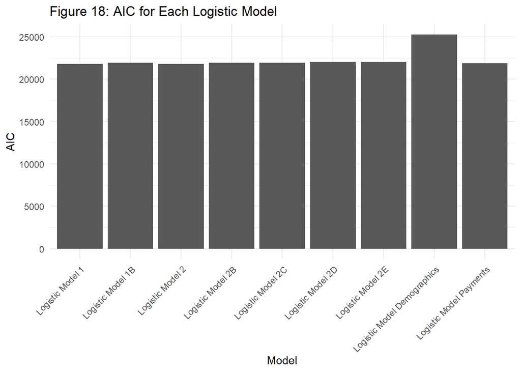

```r
# Graphs the AIC score and model.
logit.comparison %>%
  ggplot(aes(x = Model, y = AIC)) +
  geom_col() +
  ggtitle('Figure 18: AIC for Each Logistic Model') +
  theme_minimal() +
  theme(
    axis.text.x = element_text(angle = 45, hjust = 1)
  )
```

### Making Predictions with the Logistic Models

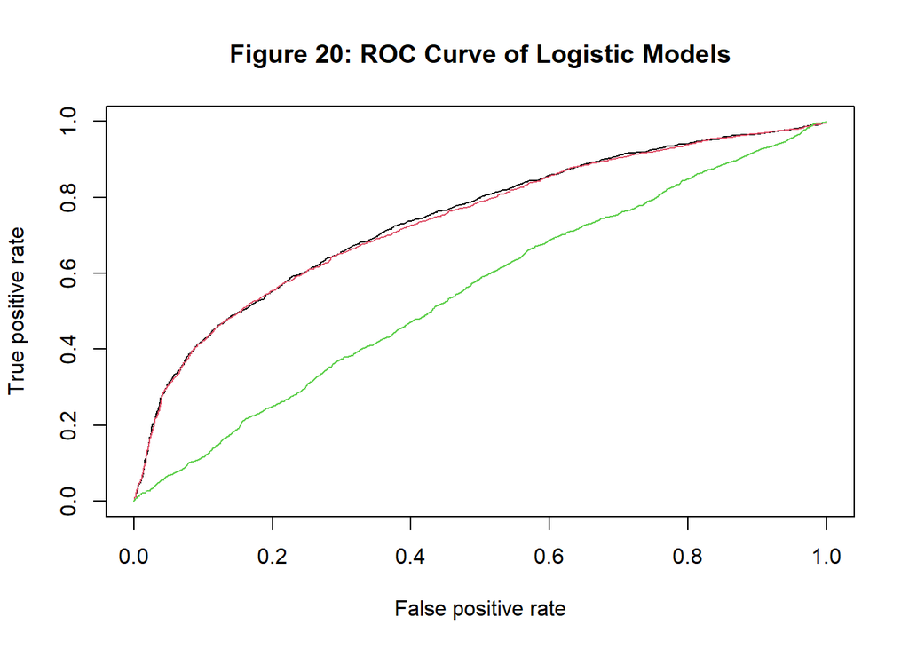

```r
# Logistic Model 2
# Logistic Model Payments
# Logistic Model Demographics



test.results <- test %>%
  mutate(

    'logistic.model2.probability' = predict(logit_model2, test_scaled, type = 'response'),
    'logistic.modelpayments.probability' = predict(logit_modelPayment, test, type = 'response'),
    'logistic.modeldemographics.probability' = predict(logit_modelDemographics, test, type = 'response')

  )

# This plots the ROC curve for Model 2
plot(
  performance(
  prediction(test.results$logistic.model2.probability, test.results$default.payment.next.month),
  'tpr',
  'fpr'
  ), colorsize = TRUE, main = 'Figure 20: ROC Curve of Logistic Models'
  )
# This adds the line for the payments model.
plot(
  performance(
  prediction(test.results$logistic.modelpayments.probability, test.results$default.payment.next.month),
  'tpr',
  'fpr'
  ), colorsize = TRUE, add = TRUE, col = 2
  )
# This adds a line for the demographics model.The demographics model is as good as guessing.
plot(
  performance(
  prediction(test.results$logistic.modeldemographics.probability, test.results$default.payment.next.month),
  'tpr',
  'fpr'
  ), colorsize = TRUE, add = TRUE, col = 3
  )
```

```r
# This line will determine the best cut-off values.
coords(roc(default.payment.next.month ~ logistic.modeldemographics.probability, data = test.results), 'best')
```

```
##   threshold specificity sensitivity
## 1 0.2181192   0.4316348   0.6604651
```

```r
coords(roc(default.payment.next.month ~ logistic.modelpayments.probability, data = test.results), 'best')
```

```
##   threshold specificity sensitivity
## 1 0.2461232   0.7845011   0.5751938
```

```r
coords(roc(default.payment.next.month ~ logistic.modeldemographics.probability, data = test.results), 'best')
```

```
##   threshold specificity sensitivity
## 1 0.2181192   0.4316348   0.6604651
```

```r
# Create predictions using the threshold value.
test.results <- test.results %>%
  mutate(
    logistic.model2.prediction = factor(ifelse(logistic.model2.probability >
                                          coords(roc(default.payment.next.month ~ logistic.modeldemographics.probability, data = test.results), 'best')[, 1], 1, 0
                                        )),

    logistic.modelpayments.prediction = factor(ifelse(logistic.modelpayments.probability >
                                                 coords(roc(default.payment.next.month ~ logistic.modelpayments.probability, data = test.results), 'best')[, 1], 1, 0
                                              )),

    logistic.modeldemographics.prediction = factor(ifelse(logistic.modeldemographics.probability >
                                                     coords(roc(default.payment.next.month ~ logistic.modeldemographics.probability, data = test.results), 'best')[, 1], 1, 0
                                                   ))
  )

# This will create confusion matrices for each logistic model.
confusionMatrix(test.results$logistic.model2.prediction, test.results$default.payment.next.month)
```

```
## Confusion Matrix and Statistics
##
##           Reference
## Prediction    0    1
##          0 3435  478
##          1 1275  812
##
##                Accuracy : 0.7078
##                  95% CI : (0.6961, 0.7193)
##     No Information Rate : 0.785
##     P-Value [Acc > NIR] : 1
##
##                   Kappa : 0.293
##
##  Mcnemar's Test P-Value : <0.0000000000000002
##
##             Sensitivity : 0.7293
##             Specificity : 0.6295
##          Pos Pred Value : 0.8778
##          Neg Pred Value : 0.3891
##              Prevalence : 0.7850
##          Detection Rate : 0.5725
##    Detection Prevalence : 0.6522
##       Balanced Accuracy : 0.6794
##
##        'Positive' Class : 0
##
```

```r
confusionMatrix(test.results$logistic.modelpayments.prediction, test.results$default.payment.next.month)
```

```
## Confusion Matrix and Statistics
##
##           Reference
## Prediction    0    1
##          0 3695  548
##          1 1015  742
##
##                Accuracy : 0.7395
##                  95% CI : (0.7282, 0.7506)
##     No Information Rate : 0.785
##     P-Value [Acc > NIR] : 1
##
##                   Kappa : 0.3179
##
##  Mcnemar's Test P-Value : <0.0000000000000002
##
##             Sensitivity : 0.7845
##             Specificity : 0.5752
##          Pos Pred Value : 0.8708
##          Neg Pred Value : 0.4223
##              Prevalence : 0.7850
##          Detection Rate : 0.6158
##    Detection Prevalence : 0.7072
##       Balanced Accuracy : 0.6798
##
##        'Positive' Class : 0
##
```

```r
confusionMatrix(test.results$logistic.modeldemographics.prediction, test.results$default.payment.next.month)
```

```
## Confusion Matrix and Statistics
##
##           Reference
## Prediction    0    1
##          0 2033  438
##          1 2677  852
##
##                Accuracy : 0.4808
##                  95% CI : (0.4681, 0.4936)
##     No Information Rate : 0.785
##     P-Value [Acc > NIR] : 1
##
##                   Kappa : 0.0565
##
##  Mcnemar's Test P-Value : <0.0000000000000002
##
##             Sensitivity : 0.4316
##             Specificity : 0.6605
##          Pos Pred Value : 0.8227
##          Neg Pred Value : 0.2414
##              Prevalence : 0.7850
##          Detection Rate : 0.3388
##    Detection Prevalence : 0.4118
##       Balanced Accuracy : 0.5460
##
##        'Positive' Class : 0
##
```

```r
# These lines of code will extract accuracy.
confusionMatrix(test.results$logistic.model2.prediction, test.results$default.payment.next.month)$overall['Accuracy']
```

```
##  Accuracy
## 0.7078333
```

```r
confusionMatrix(test.results$logistic.modelpayments.prediction, test.results$default.payment.next.month)$overall['Accuracy']
```

```
## Accuracy
##   0.7395
```

```r
confusionMatrix(test.results$logistic.modeldemographics.prediction, test.results$default.payment.next.month)$overall['Accuracy']
```

```
##  Accuracy
## 0.4808333
```

The demographic variables of sex, education, and marriage are significant predictors of default. However, the model that solely relies on demographic variables to make predicts has a low accuracy. Demographic variables are not helpful in determining who might default. While it is illegal to use demographics when deciding whether or not too issue a card, there is no financial incentive in doing so.